# Deliverable 1

# CSV FIle

CSV File is to large to be hosted on github.

# Introduction:

My choice in data has to do with flight delays. I have personally been on many flights that alwasy seem to have some sort of delay. One of the craziest delays pertained to a simple light that had gone out which caused us to completely de-plane and took hours to find a new plane.

# Data Set Info:

This dataset is on the flight delays in the year 2008. This dataset includes the exact departure times along with the schedule departure times. There is also listings of delays or cancellations allowing me to analyze the average departure time per airport.

# Data Set Variables/Units

**- Year:** 2008 (Integer)  
**- Month:** 1 - 12 (Integer)  
**- DayofMonth:** 1 - x (x = number of days in month) (Integer)  
**- DayofWeek:** 1 - 7 (1 = Monday, 7 = Sunday) (Integer)  
**- DepTime:** Exact departure time in format HHMM.SS (H = hour, M = minutes, S = seconds) (Double)  
**- CRSDepTime:** The scheduled Arrival time in format HHMM (H = hour, M = minutes) (Integer)  
**- ArrTime:** The exact Arrival time in format HHMM.SS (H = hour, M = minutes, S = seconds) (Double)  
**- CRSArrTime:** The scheduled Arrival time in format HHMM (H = hour, M = minutes) (Integer)  
**- UniqueCarrier:** The Carrier code for flight company. (EX AA = American Airlines) (Factor)  
**- FlightNum:** Flight Number (Integer)  
**- TailNum:** Tail Number (Factor)  
**- ActualElapsedTime:** Exact Flight time in minutes (Double)  
**- CRSElapsedTime:** The scheduled or estimated flight time in minutes (Double)  
**- AirTime:** Time in air in minutes (Double)  
**- ArrDelay:** The arrival delay in minutes. (Double)  
**- DepDelay:** The Departure delay in minutes. (Double)  
**- Origin:** IATA code for origin airport (Factor)  
**- Dest:** IATA code for destination airport (Factor)  
**- Distance:** Flight distance in miles (Integer)  
**- TaxiIn:** Time to taxi to gate. Represented in minutes (Double)  
**- TaxiOut:** Time to taxin to runway. Represented in minutes (Double)  
**- Cancelled:** 0 = NO 1 = YES (Integer)  
**- CancellationCode:** Cancellation Reason A = Carrier, B = weather, C = NAS(National Airspace System), D = security (Factor)  
**- Diverted:** 0 = NO, 1 = YES (Integer)  
**- CarrierDelay:** Represented in minutes (Delay ex: bird strike, baggage loading) (Double)  
**- WeatherDelay:** Represented in minutes (Delay ex: snow storm, de-icing) (Double)  
**- NASDelay:** Represented in minutes (Delay ex: Airport operations, heavy traffic) (Double)  
**- SecurityDelay:** Represented in minutes (Delay ex:Passenger screening) (Double)  
**- LateAircraftDelay:** Represented in minutes (Delay ex: head wind) (Double)

## Definitions:

**- NAS:** This stands for the National Airspace System. This system includes every airport, services, airspace rules, personell, procedures, and equipment. This sysem also includes the military. Reasons for this system causing a delay would most likely be due to a military procedure like training in an area casuing a delay to the flight path to avoid the training.

# Data Science Questions Trying to be answered:

6. Can we predict and shorten delay times by changing airlines at specific airports.

## Arrival Delay vs Departure Delay per airport

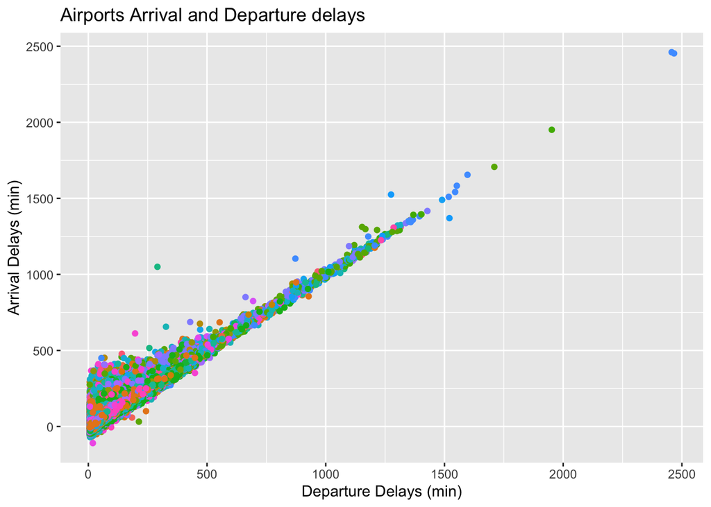

```r
 ggplot(data = df, aes(x = DepDelay, y = ArrDelay)) +
  geom_point(aes(color = Dest), show.legend = FALSE, na.rm = TRUE) +
  labs(title = "Airports Arrival and Departure delays", x = "Departure Delays (min)", y = "Arrival Delays (min)")
```

```r
print(filter(df, DepDelay > 2000))
```

```
##         X Year Month DayofMonth DayOfWeek DepTime CRSDepTime ArrTime CRSArrTime
## 1 1018798 2008     2          3         7    1117       1820    2256        555
## 2 2235378 2008     4         10         4     724       1417     858       1605
##   UniqueCarrier FlightNum TailNum ActualElapsedTime CRSElapsedTime AirTime
## 1            NW       808  N817NW               459            455     437
## 2            NW      1699  N3324L               154            168     132
##   ArrDelay DepDelay Origin Dest Distance TaxiIn TaxiOut Cancelled
## 1     2461     2457    HNL  MSP     3972      6      16         0
## 2     2453     2467    CLT  MSP      930      8      14         0
##   CancellationCode Diverted CarrierDelay WeatherDelay NASDelay SecurityDelay
## 1                N        0         1455            0        4             0
## 2                N        0         2436            0        0             0
##   LateAircraftDelay
## 1              1002
## 2                17
```